# Analysis of Cab Rides and Traffic Datasets

## Overview

### Dataset 1: Cab Rides ('cab_rides.csv')

This dataset provides a rich tapestry of data reflecting the nuances of cab service usage in an urban environment. Spanning a range of critical parameters, it captures the heartbeat of city transport through the lens of cab rides.

- **Filename**: `cab_rides.csv`
- **Contents**: The dataset encompasses detailed records of cab rides, offering a window into urban commuting patterns, customer preferences, and the operational dynamics of cab services.
- **Columns**:
  - `distance`: Measures the length of each ride, providing insights into commuting habits and the geographical spread of cab service usage.
  - `cab_type`: Differentiates between cab service providers, allowing for comparative analysis between major players like Lyft and Uber.
  - `time_stamp`: Timestamp of when the ride was booked, crucial for analyzing demand patterns across different times of the day or year.
  - `destination`: The endpoint of each journey, highlighting popular or strategic locations within the city.
  - `source`: The starting point of each ride, equally important in understanding where demand for cab services originates.
  - `price`: The cost of the ride, a vital metric for economic analysis and price modeling.
  - `surge_multiplier`: Indicates the surge pricing applied, reflecting demand-supply dynamics at different times.
  - `id`: A unique identifier for each ride, essential for data management and tracking individual rides.
  - `product_id`: Links to specific services or products offered by the cab company, useful in segmenting data based on service type.
  - `name`: The name of the cab service, giving additional context to the `product_id`.

### Dataset 2: Traffic('traffic.csv')

The traffic dataset is an extensive collection of data points that map out the flow and density of traffic, presenting a comprehensive overview of urban mobility challenges and patterns.

- **Filename**: `traffic.csv`
- **Contents**: This dataset is a compilation of various traffic metrics, offering a granular view of traffic flow and congestion in an urban landscape.
- **Columns**: These columns represent different traffic metrics (like vehicle count, speed, congestion levels) across various time slots and potentially different regions or zones in a city. The exact nature and naming of these columns would depend on the specific structure and focus of the dataset.

# Detailed Questions Analysis used in datasets

## Cab Rides Dataset ('cab_rides.csv')

### 1. What are the peak hours for cab rides?

This question aims to identify the hours of the day when cab demand is at its highest. Analyzing this can help in understanding customer behavior, optimizing cab availability, and potentially influencing pricing strategies during different times of the day.

### 2. How does the price of a cab ride vary with distance?

This analysis seeks to understand the relationship between the distance of a ride and its cost. Insights from this can inform pricing strategies, reveal if there are distance thresholds where prices significantly change, and help in understanding how customers use cab services for different trip lengths.

### 3. Comparison of different cab types in terms of price and distance.

This question focuses on comparing various cab types (like Lyft, Uber) to see how they differ in terms of pricing and the distances they are used for. Such an analysis can highlight market preferences, competition dynamics, and service niches within the cab service market.

### 4. Analysis of surge multiplier impact on pricing.

Surge pricing is a dynamic pricing strategy used to manage supply and demand. This analysis aims to understand how the surge multiplier affects the cost of rides and whether certain times or events consistently trigger surge pricing.

### 5. Identification of the most popular routes.

By identifying frequently traveled routes, this question can uncover major traffic corridors in the city, potential areas of high demand, and opportunities for targeted service enhancements.

### 6. Time series analysis of cab demand.

This involves looking at cab ride data over time to identify trends, seasonal variations, or cyclical patterns. This can inform strategic planning, marketing campaigns, and operational adjustments.

## Traffic dataset based Questions ('traffic.csv')

### 1. Calculate the correlation matrix

It represents traffic data for different locations or different traffic metrics, calculating the correlation matrix can provide valuable insights into how these different locations or metrics are related to each other.

### 2. Find the maximum traffic value

It is maximum means identifying the highest traffic measurement recorded across all locations and time points.

Calculating daily average traffic and finding the day with the lowest traffic in a dataset involves averaging the traffic data across all locations or metrics for each day, and then identifying the day with the minimum average

# Conclusion

## Reflecting on the Analysis of Cab Rides and Traffic Data

The cab rides data analysis paints a detailed picture of consumer behavior, pricing strategies, and service utilization in the urban cab service sector. By dissecting factors such as peak demand hours, price vs. distance relationships, and popular routes, we gain a nuanced understanding of how city dwellers use cab services, which can inform operational improvements and strategic planning for cab companies and city transport authorities ike.

Together, these analyses not only provide a snapshot of current urban transportation scenarios but also offer a lens through which we can anticipate future trends. As cities continue to grow and evolve, leveraging such data-driven insights will be crucial in building smarter, more efficient, and more sustainable urban environments.

```python
import pandas as pd
import matplotlib.pyplot as plt
```

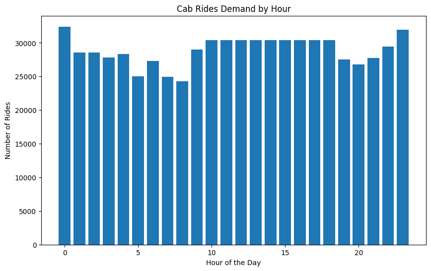

```python
# Q1. What are the peak hours for cab rides?

# Load the cab rides dataset
cab_rides_df = pd.read_csv('cab_rides.csv')  # Replace with the correct path to your dataset

# Convert the 'time_stamp' column to a datetime format
cab_rides_df['time_stamp'] = pd.to_datetime(cab_rides_df['time_stamp'], unit='ms')

# Extract the hour from the 'time_stamp' column
cab_rides_df['hour'] = cab_rides_df['time_stamp'].dt.hour

# Count the number of rides per hour
peak_hours = cab_rides_df['hour'].value_counts().sort_index()

# Plotting
plt.figure(figsize=(10, 6))
plt.bar(peak_hours.index, peak_hours.values)
plt.xlabel('Hour of the Day')
plt.ylabel('Number of Rides')
plt.title('Cab Rides Demand by Hour')
plt.show()
```

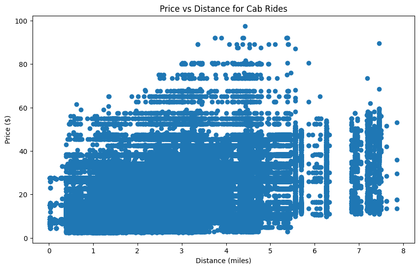

```python
# Q2.How does the price of a cab ride vary with distance?
plt.figure(figsize=(10, 6))
plt.scatter(cab_rides_df['distance'], cab_rides_df['price'])
plt.xlabel('Distance (miles)')
plt.ylabel('Price ($)')
plt.title('Price vs Distance for Cab Rides')
plt.show()
```

```
array([<Axes: title={'center': 'price'}, xlabel='cab_type'>,
       <Axes: title={'center': 'distance'}, xlabel='cab_type'>],
      dtype=object)
```

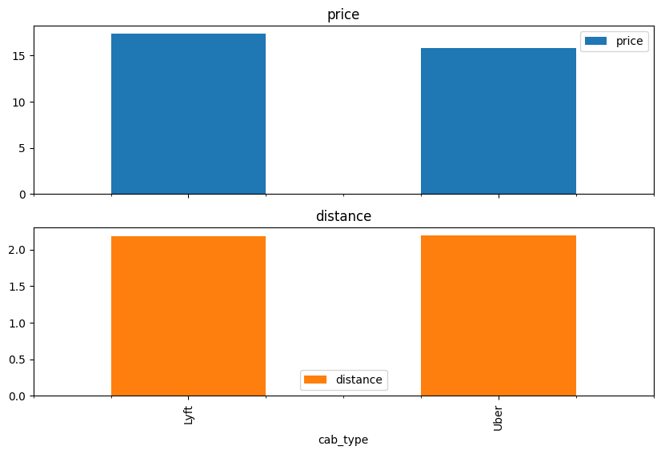

```python
# Q3.Comparison of different cab types in terms of price and distance.
cab_type_group = cab_rides_df.groupby('cab_type').agg({'price': 'mean', 'distance': 'mean'})
cab_type_group.plot(kind='bar', subplots=True, figsize=(10, 6))
```

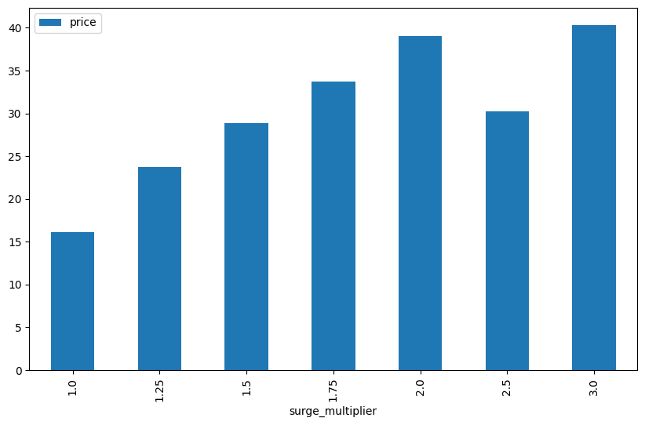

```python
#Q4. Analysis of surge multiplier impact on pricing
surge_impact = cab_rides_df.groupby('surge_multiplier').agg({'price': 'mean'})
surge_impact.plot(kind='bar', figsize=(10, 6))
```

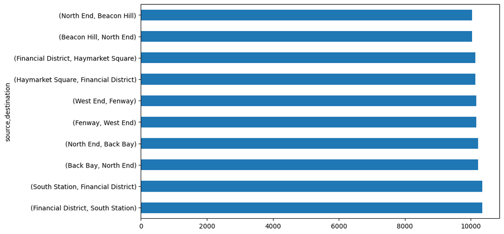

```python
# Q5.Identification of the most popular routes.
popular_routes = cab_rides_df.groupby(['source', 'destination']).size().sort_values(ascending=False).head(10)
popular_routes.plot(kind='barh', figsize=(10, 6))
```

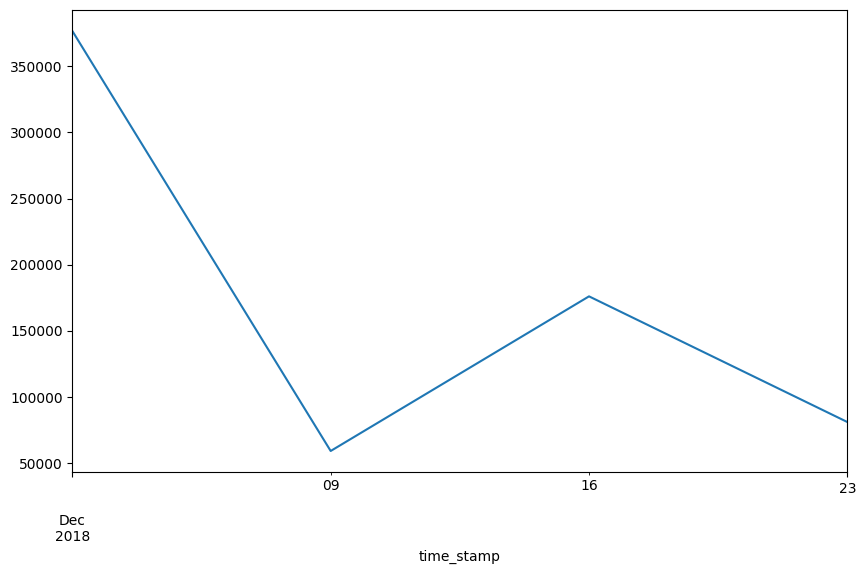

```python
# Q6. What is the time series analysis of cab demand
cab_rides_df.set_index('time_stamp', inplace=True)
weekly_demand = cab_rides_df.resample('W').size()
weekly_demand.plot(figsize=(10, 6))
```

## These are the questions for the second database "Traffic.csv".

```python
import pandas as pd
import matplotlib.pyplot as plt
import seaborn as sns
import numpy as np
traffic_data = pd.read_csv('traffic.csv')
```

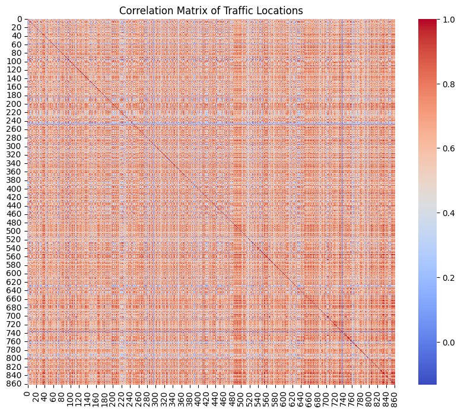

```python
# Q1. Calculate the correlation matrix
correlation_matrix = traffic_data.drop('Date', axis=1).corr()

# Plotting the correlation matrix
plt.figure(figsize=(10, 8))
sns.heatmap(correlation_matrix, cmap='coolwarm')
plt.title('Correlation Matrix of Traffic Locations')
plt.show()
```

```python
# Q2. Find the maximum traffic value
max_traffic = traffic_data.drop('Date', axis=1).max().max()

print(f"The maximum traffic recorded is: {max_traffic}")
```

```
The maximum traffic recorded is: 0.6983
```

```python
# Q3. Calculate daily average traffic and find the day with the lowest traffic
traffic_data['Daily Average'] = traffic_data.drop('Date', axis=1).mean(axis=1)
lowest_traffic_day = traffic_data[traffic_data['Daily Average'] == traffic_data['Daily Average'].min()]['Date']

print(f"The day with the lowest overall traffic is: {lowest_traffic_day.iloc[0]}")
```

```
The day with the lowest overall traffic is: 2015-02-16 02:00:00
```

```python
# Q4.Assuming the first column after 'Date' represents traffic from midnight to 1 AM
average_first_hour_traffic = traffic_data['0'].mean()

print(f"The average traffic from midnight to 1 AM is: {average_first_hour_traffic}")
```

```
The average traffic from midnight to 1 AM is: 0.043702898550724636
```